# Exploring patterns of environmental injustice

Author

Lauren Puffer

Published

November 7, 2025

## Introduction

Environmental inequities can be seen all over the world. When low income, often non-white residents disproportionately take on environmental hazards, they often experience adverse health effects and environmental degradation in their neighborhoods. This analysis aims to explore how the historic practice of redlining has influenced the environmental harms experienced by residents in Los Angeles.

In 1933, the Home Owner’s Loan Corporation created maps of metropolitan areas in the United States and categorized neighborhoods by grade. The grades were: A - best, B - still desirable, C - declining, and D - hazardous. This process has become know as “redlining.” We aim to see how redlining continues to impact the residents of Los Angeles based on their demographic makeup and the environmental injustices they face. We will do this using patial data of historically redlined neighborhoods and demographic and environmental hazard data from EJ Screen.

We will also be examining the concept that biological surveys conducted by community members are more prevalent in grade A neighborhoods, than in grade D neighborhoods. To do this we will use data from the Global Biodiveristy Information Facility gathered from eBird, a community science platform for bird observations.

## Data sources

**EJ SCREEN**  
EPA, 2024, “Environmental Justice Mapping and Screening Tool (EJScreen)”, https://doi.org/10.7910/DVN/RLR5AX, Harvard Dataverse, V4, UNF:6:Ew64oHBMGoTrNkLoYBJcUw== [fileUNF]

link to EJ Screen: https://pedp-ejscreen.azurewebsites.net/

**HOLC Red lining data**

https://dsl.richmond.edu/panorama/redlining/data

**Global Biodiversity Information Facility**

eBird: https://www.gbif.org/dataset/4fa7b334-ce0d-4e88-aaae-2e0c138d049e

## Load packages

```r
library(tidyverse)
library(sf)
library(tmap)
library(here)
library(tigris) # for shape file of counties
library(janitor) # to clean column names
library(terra)
```

# Los Angeles County block groups

EJ SCREEEN uses block groups to assess indicators of environmental justice. We will first need to pull the geometries of the block from EJ SCREEN data. Each block has a unique OBJECTID, which will provide the level of resolution required for this analysis.

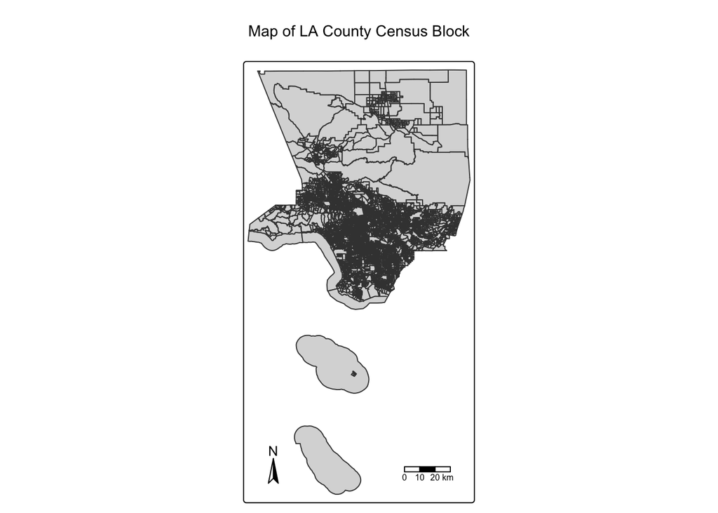

```r
# read in geodatabase of EJScreen data at the Census Block Group level
ejscreen <- st_read(here("data", "ejscreen","EJSCREEN_2023_BG_StatePct_with_AS_CNMI_GU_VI.gdb"), quiet = TRUE)

# filter for LA County
ej_screen_la <- ejscreen |>
  filter(CNTY_NAME == "Los Angeles County")

# check to see what the census blocks look like
la_county_blocks_map <- tm_shape(ej_screen_la)+
  tm_polygons()+
  tm_title(text = "Map of LA County Census Block")+
      tm_compass(type = "arrow",
               position = c("left", "bottom"),
               size = 1.5) +
    tm_scalebar(position = c("right", "bottom"),
                width = 6)

la_county_blocks_map
```

# Redlining in Los Angeles

Anytime we are working with spatial data, we need to make sure that the coordinate reference systems are the same for accuracy purposes. In order to do this we must check the CRS of each shape file we are working with and then make them match.

```r
# redlining data from HOLC
redlining <- st_read(here("data", "mapping-inequality","mapping-inequality-los-angeles.json"), quiet = TRUE)

# check CRS of HOLC redlining data
st_crs(redlining)
```

```
Coordinate Reference System:
  User input: WGS 84
  wkt:
GEOGCRS["WGS 84",
    DATUM["World Geodetic System 1984",
        ELLIPSOID["WGS 84",6378137,298.257223563,
            LENGTHUNIT["metre",1]]],
    PRIMEM["Greenwich",0,
        ANGLEUNIT["degree",0.0174532925199433]],
    CS[ellipsoidal,2],
        AXIS["geodetic latitude (Lat)",north,
            ORDER[1],
            ANGLEUNIT["degree",0.0174532925199433]],
        AXIS["geodetic longitude (Lon)",east,
            ORDER[2],
            ANGLEUNIT["degree",0.0174532925199433]],
    ID["EPSG",4326]]
```

```r
# check and transform CRS
if(crs(redlining) == crs(ej_screen_la)){
  print("Coordinate reference systems match.")
}else{
  warning("Updating coordinate reference systems to match.")
  #transform data to match
  redlining_reproj <- st_transform(redlining, st_crs(ej_screen_la))
}
```

Now that the CRS’s match, we can begin building a map to show the distribution of the historically redlined neighborhoods in LA. Because LA county is much bigger than the scope of this redlining data, we will create a bounding box on our map that restricts it to the extent of the HOLC redlining data.

```r
# get the bounding box of HOLC data
holc_extent <- st_bbox(redlining_reproj)
```

Now that we have our bounding box, we can begin creating our map using the hex codes of colors provided in the HOLC redlining dataset for each corresponding grade.

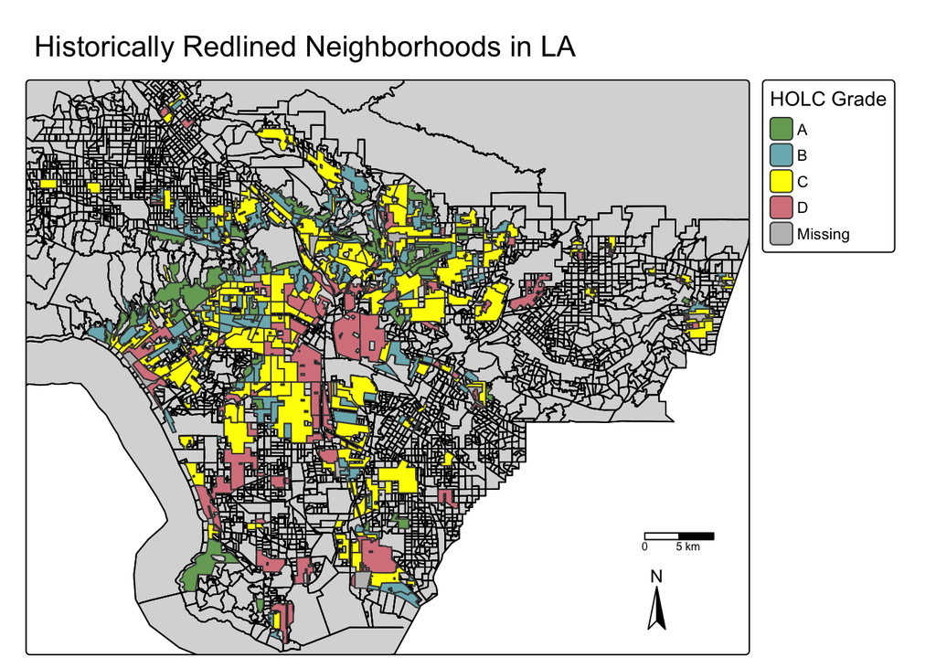

```r
# use colors from HOLC dataset
# Define the custom colors for each grade
grade_colors <- c(
  "A" = "#76a865",
  "B" = "#7cb5bd",
  "C" = "#ffff00",
  "D" = "#d9838d",
  "None" = "#d3d3d3"
)

# create a map of all the HOLC neighborhoods and their grades in LA
tm_shape(ej_screen_la, bbox = holc_extent) +
  tm_polygons() +
  tm_borders(col = "black")+
  tm_shape(redlining_reproj)+
  tm_fill(col = "grade", palette = grade_colors, title = "HOLC Grade")+
  tm_title(text = "Historically Redlined Neighborhoods in LA")+
  tm_scalebar(position = c("right", "bottom"),
              width = 7)+
   tm_compass(type = "arrow",
               position = c("right", "bottom"))
```

You may notice that the HOLC data is only a very small portion of LA County. This is because the HOLC data is from decades ago, when LA was much smaller. We need to account for this in our analysis by only including block groups from the HOLC data.

## Join redlining and EJ Screen Data

Because we want to have all of the census blocks for our HOLC data, we will join the two data sets so that we can use the census block geometries in the EJ Screen data and perform analyses.

```r
# join HOLC and EJ Screen data
holc_ej <- st_join(redlining_reproj, ej_screen_la, join = st_intersects, left = FALSE) |>
clean_names()

# 6388 observations and 238 variables
```

Now that we have joined the datasets, we can gather the information we need to get the percentage of each grade across the census block in LA.

```r
# group by grade and get percentage of each grade in LA county
holc_by_block <- holc_ej |>
  st_drop_geometry() |>
  mutate(grade = replace_na(grade, "None")) |>   # handle NA here
  group_by(grade) |>
  summarise(num_blocks = n())|>
  mutate(percentage = num_blocks / sum(num_blocks) * 100)
```

## Percentage of blocks in each grade

To better illustrate what this looks like, we will construct a table that will show the number of blocks and percentage of blocks in each grade.

```r
# package that allows you to make interactive data tables
library(DT)

# create data table with information from 'holc_by_block' data frame
datatable(holc_by_block,
          options = list(pageLength = 5, autoWidth = TRUE),
          rownames = FALSE,
          class = "stripe hover",
          colnames = c("HOLC Grade", "Number of Block Groups", "Percent of Total"))
```

| HOLC Grade | Number of Block Groups | Percent of Total |
| --- | --- | --- |
| A | 449 | 7.028804007514089 |
| B | 1239 | 19.39574201628053 |
| C | 3058 | 47.87100814026299 |
| D | 1346 | 21.07075767063244 |
| None | 296 | 4.633688165309956 |

You can see that block grade C represents much of the nieghborhoods in the city of Los Angeles. Block groups with that belong to grade C are thought to be in decline.

# Redlining and EJ

In order to illustrate the relationship between different EJ indicators and how they are impacted by redlining, we will create some meaningful visuals. The first will be a bar graph illustrating the average percentage of low income residents in each block grade across LA.

## Percent low income by grade

We want to get the average percent of low income residents in each HOLC grade. This is because it will make for a much nicer and easier to digest visual. In order to do this, we must drop the geometry of this datacset and get the mean of the value.

```r
# get percent low income by grade
percent_lowinc_by_grade <- holc_ej |>
  st_drop_geometry() |>
  mutate(grade = if_else(is.na(grade), "None", grade)) |>
  group_by(grade) |>
  summarise(avg_lowincpct = mean(lowincpct, na.rm = TRUE) * 100)
```

Now that we have a data set compatible for making bar graphs, we can make our visualization in ggplot.

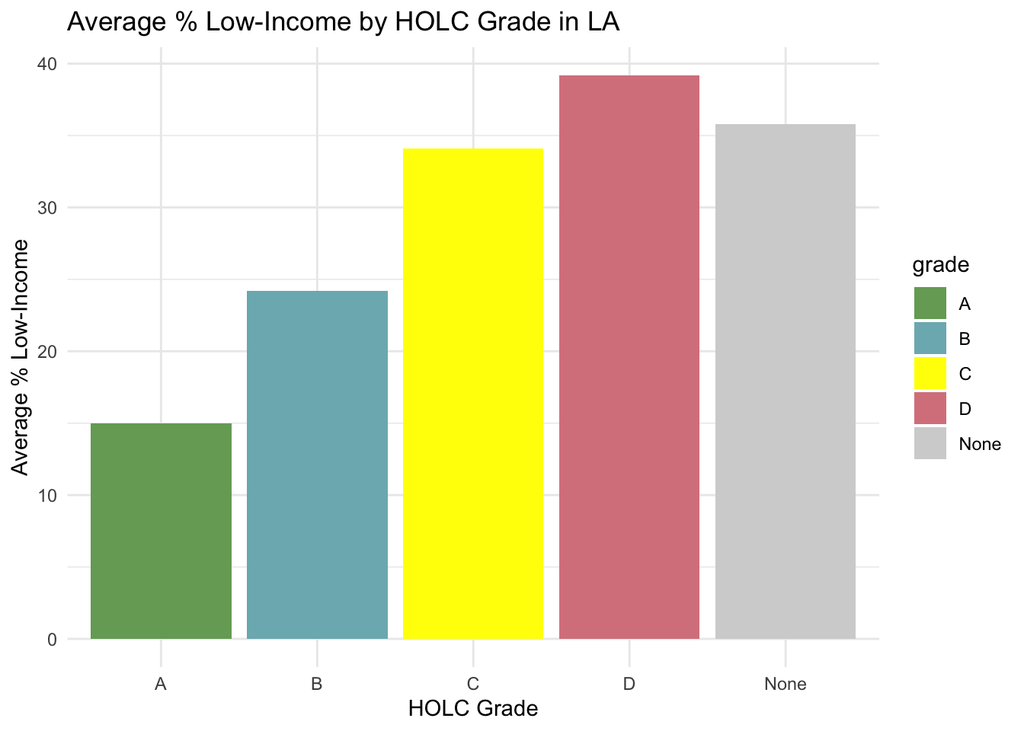

```r
# plot bar graph of percent low income by grade
holc_percent_low_inc <- ggplot(percent_lowinc_by_grade, aes(x = grade, y = avg_lowincpct, fill = grade)) +
  geom_col() +
  labs(
    title = "Average % Low-Income by HOLC Grade in LA",
    x = "HOLC Grade",
    y = "Average % Low-Income"
  ) +
  scale_fill_manual(values = grade_colors) +   # use custom colors here
  theme_minimal()

# call the plot
holc_percent_low_inc
```

As we can see, grade A, which the ‘best’ neighborhoods belong to, has the lowest average percent low income at ~ 15%, while grade D, which the ‘hazardous’ neighborhoods belong to has the highest average percent low income.

## Percentile for PM 2.5 and low life expectancy by grade

```r
# get percentile for PM 2.5 and low life expectancy by grade
pm25_lifeexp_by_grade <- holc_ej |>
  st_drop_geometry() |>
  mutate(grade = if_else(is.na(grade), "None", grade))
```

Now that we have a data frame with the percentile of PM 2.5 exposure and low life expectancy for each grade, we can easily visualize the data with box plots. Box and whisker plots allow use to see how the data is distributed across all of the blocks. The line in each box tells us the median of the data and the box represents where 50% of the data lies.

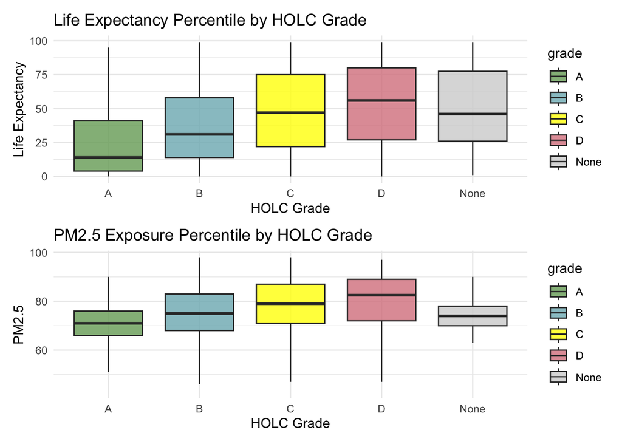

```r
# box plot for percentile low life expectancy by grade
life_exp_box <- ggplot(pm25_lifeexp_by_grade, aes(x = grade, y = p_lifeexppct, fill = grade)) +
  geom_boxplot(outlier.shape = NA, alpha = 0.8) +  # hide outliers
  scale_fill_manual(values = grade_colors) +
  labs(
    title = "Life Expectancy Percentile by HOLC Grade",
    x = "HOLC Grade",
    y = "Life Expectancy"
  ) +
  theme_minimal()

# box plot for percentile pm 2.5 exposure by grade
pm25_box <- ggplot(pm25_lifeexp_by_grade, aes(x = grade, y = p_pm25, fill = grade)) +
  geom_boxplot(outlier.shape = NA, alpha = 0.8) + # hide outliers
  scale_fill_manual(values = grade_colors) +
  labs(
    title = "PM2.5 Exposure Percentile by HOLC Grade",
    x = "HOLC Grade",
    y = "PM2.5"
  ) +
  theme_minimal()

# load patchwork to show both plots
library(patchwork)

# call the plots
print(life_exp_box / pm25_box)
```

## Discussion

As we can see in these two box plots, the spread of data is much narrower for percentile of PM 2.5 exposure than for percentile low life expectancy. This illustrates that low life expectancy may not be that closely related to HOLC grade, however, there still may be some correlation. Residents from block groups in grade D seem to experience lower life expectancies than any other grade. Residents from block groups in grade A tend to not have a positive relationship with low life expectancy they way the other grades do.

PM 2.5 is marginally different between the grades, but still we see the same trend repeating, wherein grade A experiences less PM 2.5 exposure compared with other grades. Block groups belonging to no grade seem to take the average of every value we have visualized. This shows us that redlining, which happened decades ago, is still impacting the livelihoods of residents in Los Angeles currently. Defining a neighborhood as ‘hazardous’ or ‘declining’ is almost a self-fulfilling prophecy. Because of this categorization of neighborhoods back in the 1930s, these block groups do not see the investments in infrastructure and policies that could improve their environment.

Ultimately, this narrative that began so long ago is still affecting residents today. This harmful narrative perpetuates as low income residents continue to be overburdened with environmental harms.

# Birds in Los Angeles County

In order to observe the relationship between bird observations and HOLC grades. We are ultimately getting at two questions here: 1) Is community science prevalent in these areas? and 2) Do neighborhoods with different HOLC grades experience sampling bias?

## Joining HOLC and Bird data

First we will load our community bird observations from the Global Biodiversity Information Facility. The bird observations we have come from 2021 - 2023. For the purposed of this analysis, we will not be looking at their temporal differences and will instead treat them all the same across year. Then we will make sure that the CRS’s match for our HOLC redlining data and our bird data. After that, we will join this data set with our HOLC data set in order to get the geometries for both.

```r
# read in bird data
birds <- st_read(here("data", "gbif-birds-LA",
                      "gbif-birds-LA.shp"), quiet = TRUE)

# check the CRS of bird data
st_crs(birds)
```

```
Coordinate Reference System:
  User input: WGS 84
  wkt:
GEOGCRS["WGS 84",
    DATUM["World Geodetic System 1984",
        ELLIPSOID["WGS 84",6378137,298.257223563,
            LENGTHUNIT["metre",1]]],
    PRIMEM["Greenwich",0,
        ANGLEUNIT["degree",0.0174532925199433]],
    CS[ellipsoidal,2],
        AXIS["latitude",north,
            ORDER[1],
            ANGLEUNIT["degree",0.0174532925199433]],
        AXIS["longitude",east,
            ORDER[2],
            ANGLEUNIT["degree",0.0174532925199433]],
    ID["EPSG",4326]]
```

```r
# check and transform CRS
if(crs(birds) == crs(redlining_reproj)){
  print("Coordinate reference systems match.")
}else{
  warning("Updating coordinate reference systems to match.")
  #transform data to match
  birds_reproj <- st_transform(birds, st_crs(redlining_reproj))
}
```

Now that we have transformed our geometries to have the same projection and CRS, we can join our data sets.

```r
# join HOLC and birds data sets
holc_bird <- st_join(birds_reproj, redlining_reproj, join = st_intersects, left = FALSE) |>
clean_names()

# change NAs to "None" for 'grade' column
holc_bird <- holc_bird |>
  mutate(grade = replace_na(grade, "None"))
```

Now that our data sets look the way we want them to and none of the observations for ‘grade’ contain NAs, we can drop our geometries and do our statistical analysis.

First, we need to get the percentage of bird observations represented in each HOLC grade. This will be similar to the table we made to see the percentage of block groups belonging to each HOLC grade.

```r
# group by grade and get percentage of bird observations in each
bird_by_holc <- holc_bird |>
  st_drop_geometry() |>
  group_by(grade) |>
  summarise(num_obs = n()) |>
  mutate(percentage = num_obs / sum(num_obs) * 100)
```

## Bird observations by HOLC grade

Now, we will be making a bar graph that shows the percentage of total bird observations from each HOLC grade in Los Angeles. This will be very similar to our average low income percentage bar graph, but this will not be the average.

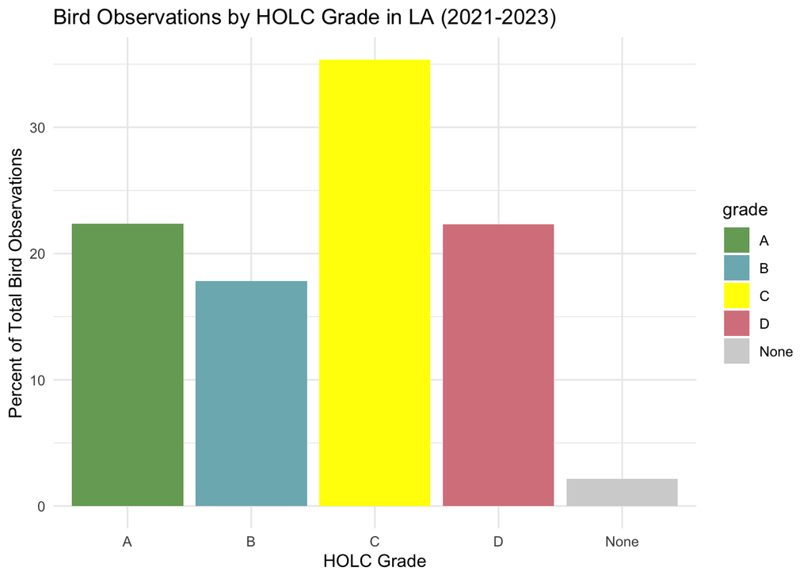

```r
# plot bar graph of percent total bird observations by HOLC grade
holc_percent_bird <- ggplot(bird_by_holc, aes(x = grade, y = percentage, fill = grade)) +
  geom_col() +
  labs(
    title = "Bird Observations by HOLC Grade in LA (2021-2023)",
    x = "HOLC Grade",
    y = "Percent of Total Bird Observations"
  ) +
  scale_fill_manual(values = grade_colors) +   # use custom colors here
  theme_minimal()

# call the plot
holc_percent_bird
```

Looking at our bar graph, there is not an apparent relationship between HOLC grade and bird observations. We see that “declining” neighborhoods actually have a higher proportion of bird observations than those that are “best” or “still desirable.” Still the “hazardous neighborhoods have almost the same proportion of bird observations as the”best” neighborhoods.

## Discussion

The results that we have found in our analysis differ greatly from the work of Ellis-Soto et al. 2023. The authors of this paper concluded that grade A neighborhoods had twice the amount of bird observations as grade D neighborhoods. We clearly do not show that in our analysis. The reason for this difference is largely because of a difference in methodology. If you look at bird observations in a vacuum, as we have, and you don’t consider the density of each of these areas, you get different results. Additionally, our analysis has only looked at Los Angeles, and the Ellis-Soto et al. paper looked at 195 areas across 35 states. They also accounted for differences in vegetation, open space, population density, and climate.

A difference in methodology will often produce a difference in results. Ultimately, our analysis does not negate the results of the Ellis-Soto et al. paper because we are measuring different values. Sampling density is much different than number of birds sampled.

**References**

Ellis-Soto, D., Chapman, M. & Locke, D.H. Historical redlining is associated with increasing geographical disparities in bird biodiversity sampling in the United States. *Nat Hum Behav* **7**, 1869–1877 (2023). https://doi.org/10.1038/s41562-023-01688-5